# Final Project Part 2

Alex Fink

12/5/2021

```r
library(readr)
delomys <- read_csv("data/delomys.csv")
```

```
## * `` -> ...1
```

```r
View(delomys)


body_mass = summary(delomys$body_mass)
body_mass
```

```
##    Min. 1st Qu.  Median    Mean 3rd Qu.    Max.
##    5.00   35.00   43.00   44.06   54.00  105.00
```

```r
body_length = summary(delomys$body_length)
body_length
```

```
##    Min. 1st Qu.  Median    Mean 3rd Qu.    Max.
##    49.0   106.0   116.0   114.7   124.0   265.0
```

```r
shapiro.test(body_mass)
```

```
##
##  Shapiro-Wilk normality test
##
## data:  body_mass
## W = 0.9099, p-value = 0.4357
```

```r
shapiro.test(body_length)
```

```
##
##  Shapiro-Wilk normality test
##
## data:  body_length
## W = 0.80354, p-value = 0.06323
```

## Scatterplot by body mass and length

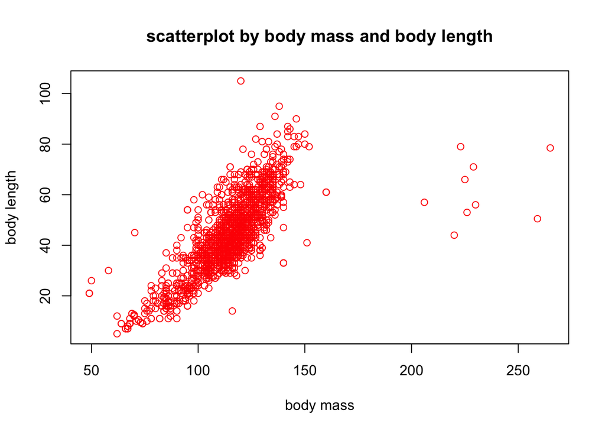

```r
plot(body_mass~body_length, data = delomys,xlab = "body mass",ylab = "body length", main = "scatterplot by body mass and body length", col = "red")
```

## Histogram of body mass

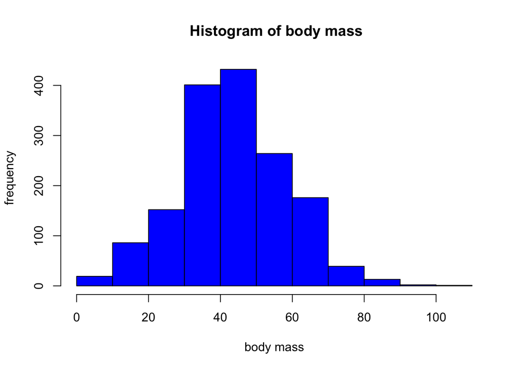

```r
hist(delomys$body_mass, xlab = "body mass", ylab = "frequency", main = " Histogram of body mass", col = "blue")
```

## Histogram of body length

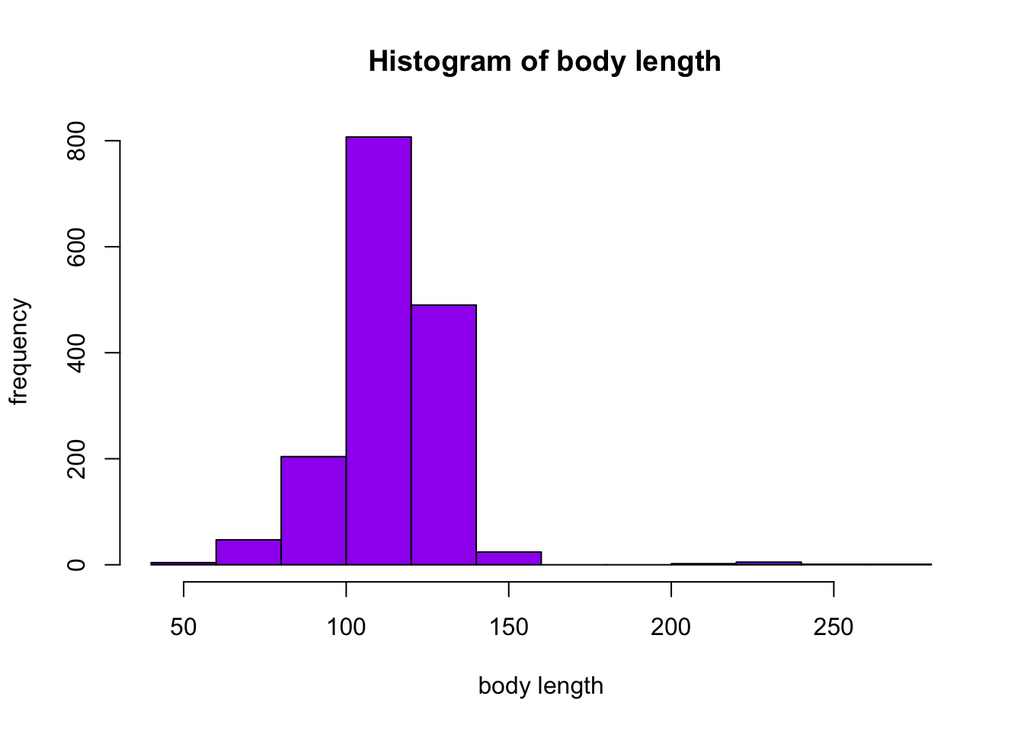

```r
hist(delomys$body_length, xlab = "body length", ylab = "frequency", main = " Histogram of body length", col = "purple")
```

## Conditional boxplot of species on body mass

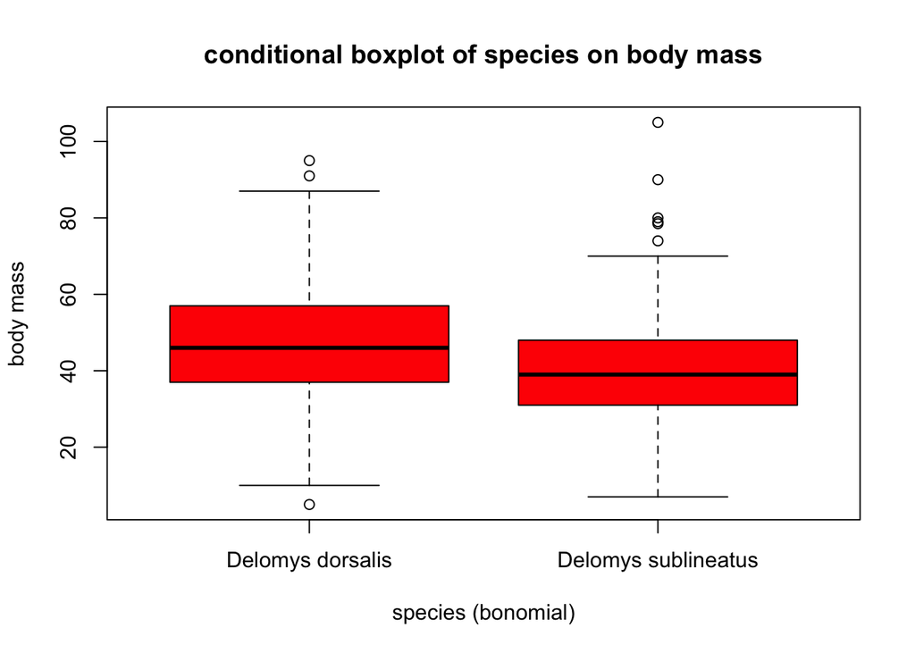

```r
boxplot(body_mass~binomial,data = delomys,xlab = "species (bonomial)",ylab = "body mass", main = "conditional boxplot of species on body mass",col = "red" )
```

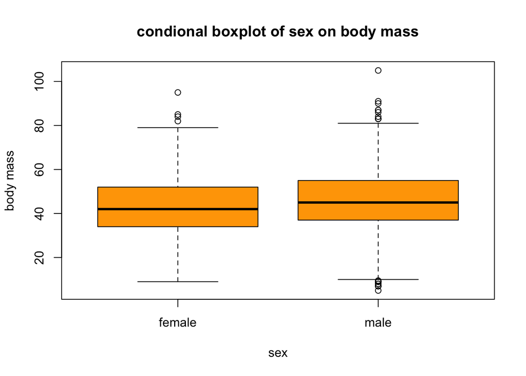

```r
boxplot(body_mass~sex,data = delomys, xlab = "sex", ylab = "body mass", main = "condional boxplot of sex on body mass",col = "orange")
```

## Conditonal boxplot of sex and species

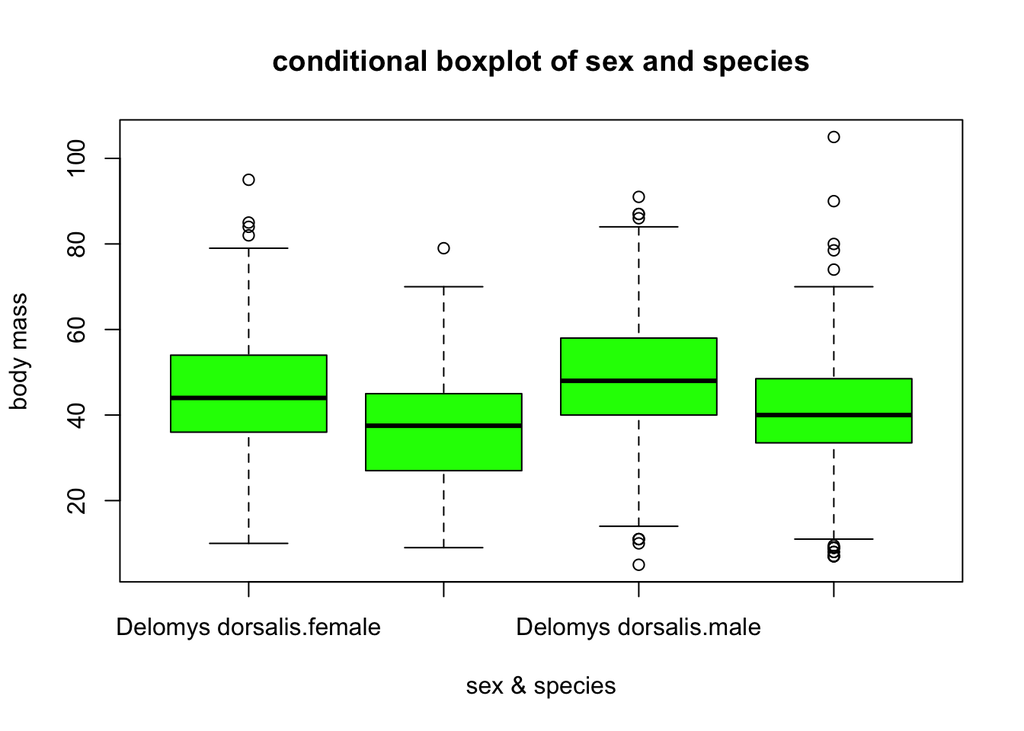

```r
boxplot(body_mass~binomial*sex,data = delomys, xlab = "sex & species",ylab = "body mass", main = "conditional boxplot of sex and species", col = "green")
```

# Questions 1-4

## Q2:The histogram of body mass is normally distributed because most of the points fall within the mean. The histogram of length is not normally distributed, the pvalues are not near the mean.

## Q3:I think body mass is normally distributed because the graph looks pretty even where length is very spread out.

# Model Building

## Simple linear regression

```r
fit_1 =
  lm(
    formula = body_length ~ body_mass,
    data = delomys)
```

ANOVA

```r
fit_2 =
  lm(
    formula =  body_mass ~ sex,
    data = delomys)

fit_3 =
  lm(
    formula =  body_mass ~ binomial,
    data = delomys)

fit_4 =
  lm(
    formula = body_mass ~ sex + binomial,
    data = delomys)

fit_5 =
  lm(
    formula = body_mass ~ sex * binomial,
    data = delomys)
```

```r
## Residual histograms
```

```r
head(residuals(fit_1))
```

```
##          1          2          3          4          5          6
## 138.662657  77.710942  79.971915  90.714932 -20.152587  -1.899594
```

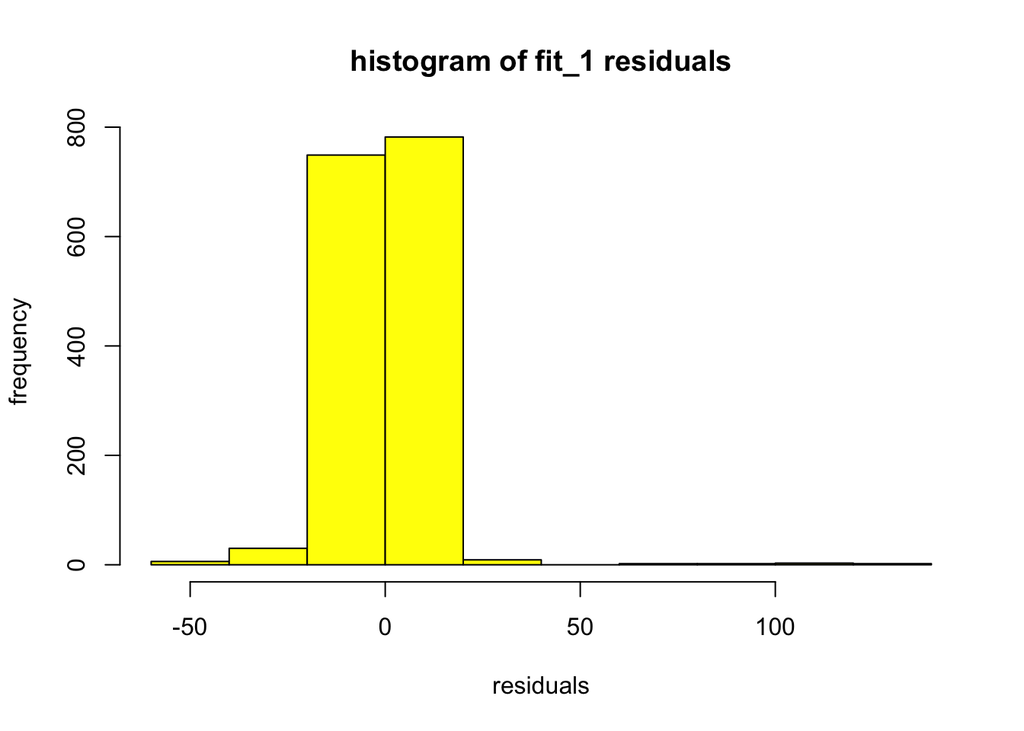

```r
hist(fit_1$residuals, xlab = "residuals",ylab = "frequency",main = "histogram of fit_1 residuals",col = "yellow")
```

```r
head(residuals(fit_2))
```

```
##         1         2         3         4         5         6
##  7.788535 36.288535 14.288535 25.504403 10.504403  4.504403
```

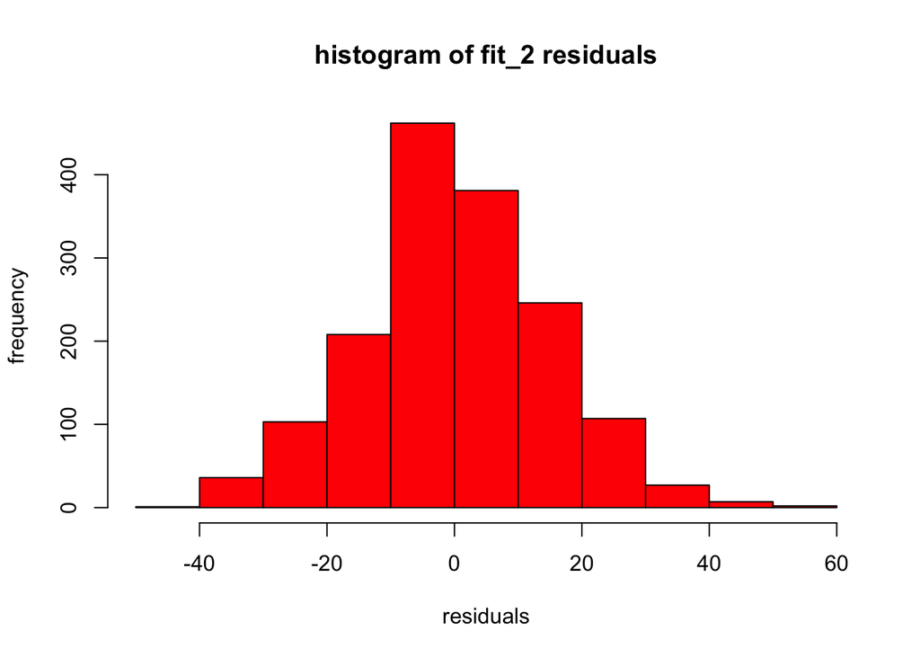

```r
hist(fit_2$residuals, xlab = "residuals",ylab = "frequency",main = "histogram of fit_2 residuals",col = "red")
```

```r
head(residuals(fit_3))
```

```
##         1         2         3         4         5         6
##  3.747573 32.247573 10.247573 24.247573  9.247573  3.247573
```

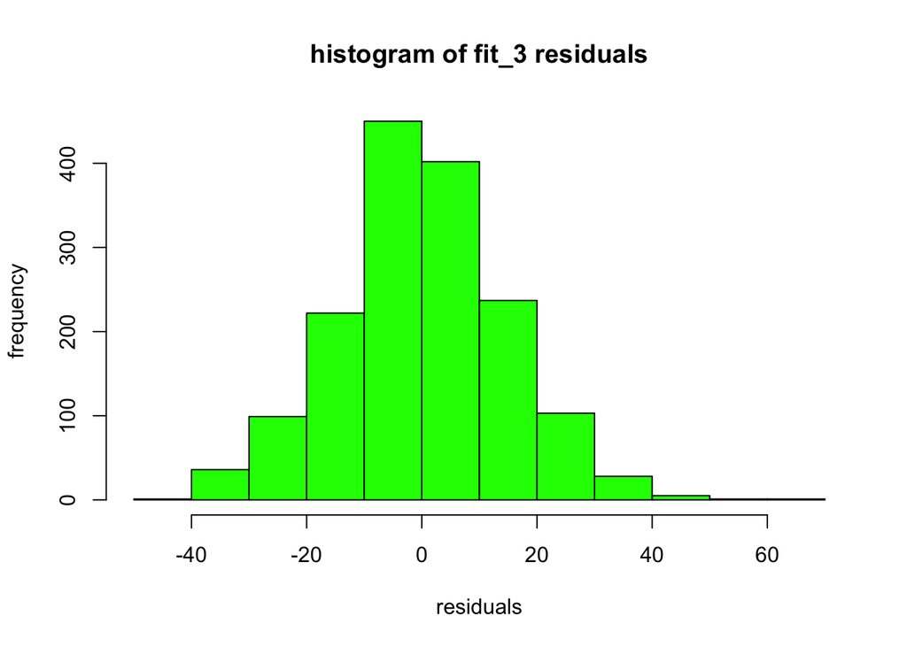

```r
hist(fit_3$residuals, xlab = "residuals",ylab = "frequency",main = "histogram of fit_3 residuals",col = "green")
```

```r
head(residuals(fit_4))
```

```
##         1         2         3         4         5         6
##  5.429644 33.929644 11.929644 22.134249  7.134249  1.134249
```

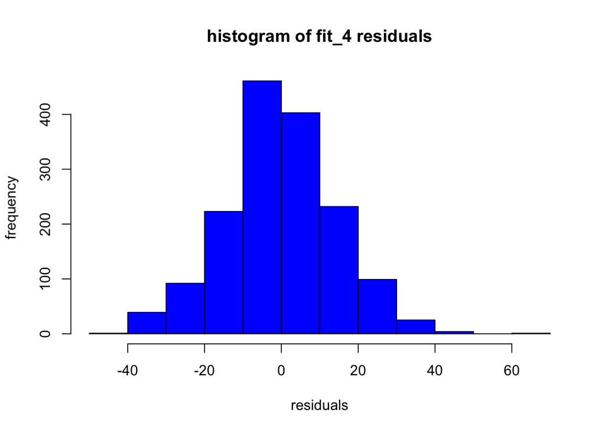

```r
hist(fit_4$residuals, xlab = "residuals",ylab = "frequency",main = "histogram of fit_4 residuals",col = "blue")
```

```r
head(residuals(fit_5))
```

```
##         1         2         3         4         5         6
##  5.444544 33.944544 11.944544 22.116453  7.116453  1.116453
```

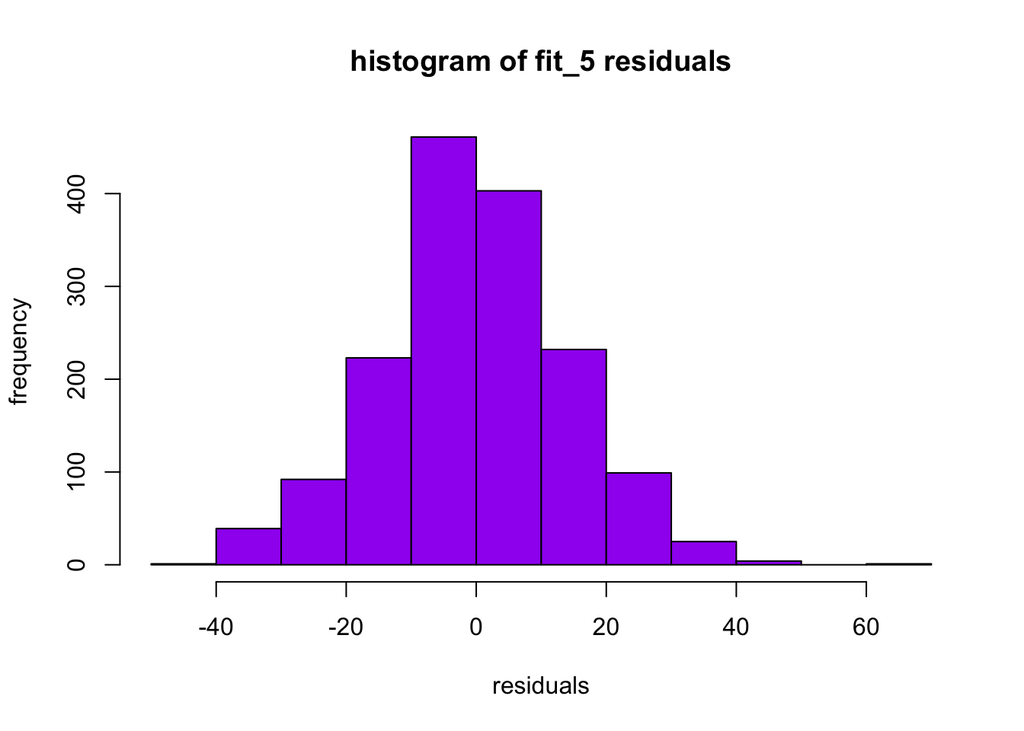

```r
hist(fit_5$residuals, xlab = "residuals",ylab = "frequency",main = "histogram of fit_5 residuals",col = "purple")
```

## Shapiro test

```r
shapiro.test(fit_1$residuals)
```

```
##
##  Shapiro-Wilk normality test
##
## data:  fit_1$residuals
## W = 0.73462, p-value < 2.2e-16
```

```r
shapiro.test(fit_2$residuals)
```

```
##
##  Shapiro-Wilk normality test
##
## data:  fit_2$residuals
## W = 0.99563, p-value = 0.0001541
```

```r
shapiro.test(fit_3$residuals)
```

```
##
##  Shapiro-Wilk normality test
##
## data:  fit_3$residuals
## W = 0.99535, p-value = 8.103e-05
```

```r
shapiro.test(fit_4$residuals)
```

```
##
##  Shapiro-Wilk normality test
##
## data:  fit_4$residuals
## W = 0.99525, p-value = 6.805e-05
```

```r
shapiro.test(fit_5$residuals)
```

```
##
##  Shapiro-Wilk normality test
##
## data:  fit_5$residuals
## W = 0.99526, p-value = 6.816e-05
```

# Questions 5-6

Q5:I conclude that each residual graphically is normal except for fit_1. Numerically they are not normal looking at the p-values.

Q6:The violations of normality assumption is not as severe for all of the models,because only the fit_1 graph is skewed and the p-value is low and not significant.

|  | Estimate | Std. Error | t value | Pr(>\|t\|) |
| --- | --- | --- | --- | --- |
| (Intercept) | 76.12 | 0.92 | 83.12 | 0 |
| body_mass | 0.88 | 0.02 | 44.46 | 0 |

```
## [1] 76.12
```

|  | Estimate | Std. Error | t value | Pr(>\|t\|) |
| --- | --- | --- | --- | --- |
| (Intercept) | 46.75 | 0.45 | 103.9 | 0 |
| binomialDelomys sublineatus | -7.68 | 0.76 | -10.1 | 0 |

# Questions 7-9

Q7:The magnitude of the mass/length relationship is 0.88

Q8:The expected length of animal that weighs 100g is 164.12

Q9:The expected length of animal that weighs 0g is 76.12

# Questions 10-13

Q10:The base level for sex is 42.71

Q11:The base case for binomial is 46.75

Q13:The heavier species is Dorsalis

# Questions 14-16

```r
fit_1
```

```
##
## Call:
## lm(formula = body_length ~ body_mass, data = delomys)
##
## Coefficients:
## (Intercept)    body_mass
##     76.1247       0.8755
```

```r
fit_2
```

```
##
## Call:
## lm(formula = body_mass ~ sex, data = delomys)
##
## Coefficients:
## (Intercept)      sexmale
##      42.711        2.784
```

```r
fit_3
```

```
##
## Call:
## lm(formula = body_mass ~ binomial, data = delomys)
##
## Coefficients:
##                 (Intercept)  binomialDelomys sublineatus
##                      46.752                       -7.683
```

```r
fit_4
```

```
##
## Call:
## lm(formula = body_mass ~ sex + binomial, data = delomys)
##
## Coefficients:
##                 (Intercept)                      sexmale
##                      45.070                        3.795
## binomialDelomys sublineatus
##                      -8.193
```

```r
fit_5
```

```
##
## Call:
## lm(formula = body_mass ~ sex * binomial, data = delomys)
##
## Coefficients:
##                         (Intercept)                              sexmale
##                            45.05546                              3.82809
##         binomialDelomys sublineatus  sexmale:binomialDelomys sublineatus
##                            -8.14174                             -0.09502
```

Q14:Sex and species are a good predictor of body mass if you are looking at p-values. If you are looking at the graphs, sex and species are not good predictors because all the boxes are about the same size and spread.

Q15:There is not a significant interaction between sex and species.

Q16:The significance measured by the p-values of either main effects differ between the single-predictor models, the additive model,and the interactive model is they don’t really differ in p-values.they are all less than.05 which means I can reject the null. With different models you are getting more information.

## Model Comparison: Body Mass

```r
AIC(fit_1)
```

```
## [1] 12291.67
```

```r
AIC(fit_2)
```

```
## [1] 13006.8
```

```r
AIC(fit_3)
```

```
## [1] 12966.36
```

```r
AIC(fit_4)
```

```
## [1] 12896.73
```

```r
AIC(fit_5)
```

```
## [1] 12898.72
```

# Questions 17-18

Q17:The two models with the lowest AIC are fit_4 and fit_5

Q18:Out of the two models I would choose fit_4 because, AIC values are similar but fit_4 is my additive model which is more simple than fit_5 which is the interactive.